# Statistical inference, bootstrap

## Topics of this lecture

- A review of statistical inference concepts
  - Parameters and statistics
  - Hypothesis testing, confidence intervals
- Resampling
  - Bootstrap
  - Program bootstrap function

## A review of inference concepts

## Parameters and statistics

**Random sample**

- set of values drawn independently from a population

**Population parameter**

- Property of the population (e.g. \(\mu,\sigma,\rho\))

**Sample statistic**

- Property of the sample (e.g. \(\bar{x},s,r\))

**Standard error**

- Variability of a sample statistic

## Sampling distribution

The sampling distribution is the distribution of a sample statistic (e.g. mean, standard deviation)

Take many random samples from population and compute mean -> **sampling distribution** of the mean

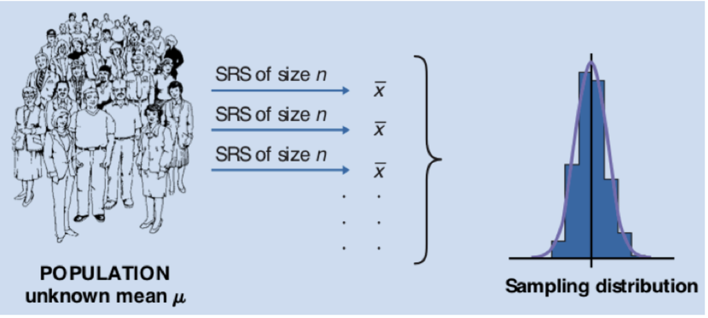

## Central Limit Theorem

- **Given a distribution with mean \(\mu\) and standard deviation \(\sigma\), the sampling distribution of the mean approaches a normal distribution with mean \(\mu\) and standard deviation \(\frac{\sigma}{\sqrt{n}}\) as \(n\to\infty\)**

Conditions for the CLT to hold

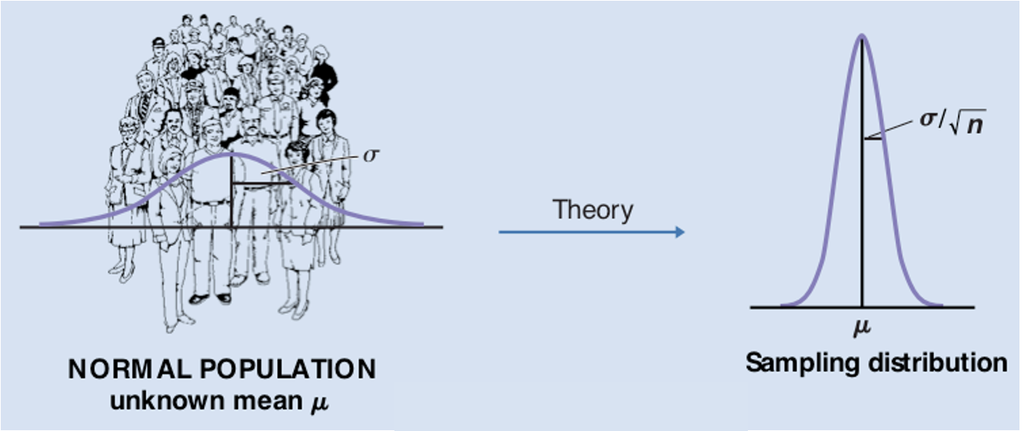

## Hypothesis test, confidence interval

Using the properties of the normal distribution (95% of the observations are within approximately 2 standard deviations around the mean \(\bar{x}\)), we compute a 95% confidence interval with the sampling statistics:

\(\bar{x} \pm 1.96 \cdot \text{SE}\), where \(\text{SE} = s / \sqrt{n}\)

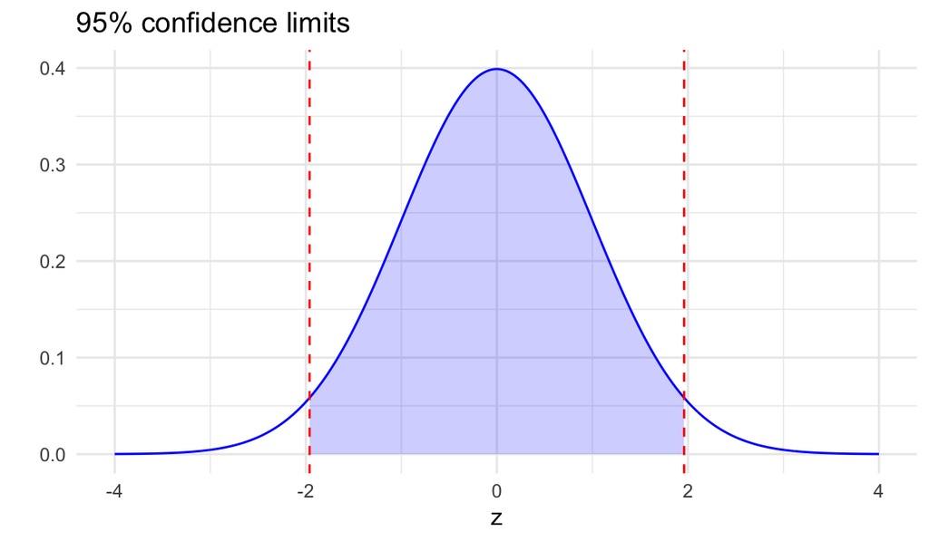

## Bootstrap

## When to use the Bootstrap

- If classical inference theory fails (assumptions are violated), statistical inference is still possible using resampling techniques to obtain standard errors, confidence intervals, and test hypotheses (example: median)
- Use the bootstrap to obtain the sampling distribution for a statistic.
- Use the bootstrap distribution to obtain standard errors and 95% confidence intervals.

## Basic idea bootstrap resampling

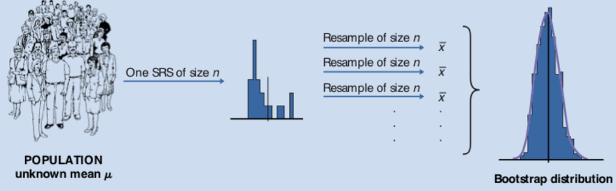

When there is **only one sample** and theory fails:

- The sample stands for the population
- The **bootstrap distribution** stands for sampling distribution
- Substitute computing power for theoretical analysis

## The bootstrap: a resampling technique

Baron Münchausen has fallen in a lake and pulls himself and his horse up by his bootstrap (or hair).

[figure not shown]

Rudolph Erich Raspe, Münchausen (1763)

## Bradley Efron

### Inventor of the bootstrap resampling technique

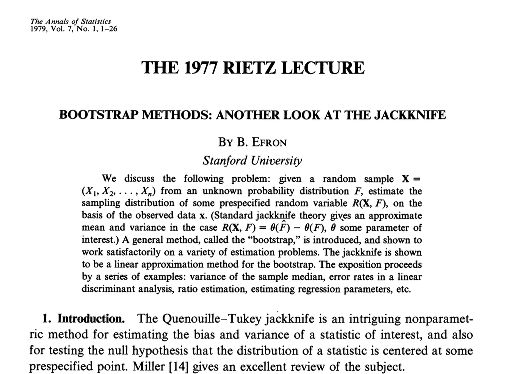

## How to bootstrap?

1. Take a sample of size *n* with replacement from the sample (size *n*)
2. Fit the model and save the statistic(s) of interest (e.g. \(\bar{x}\))
3. Use a loop to repeat sampling *B* times (*B* = 1000)
4. The *B* values of \(\bar{x}\) form the bootstrap distribution

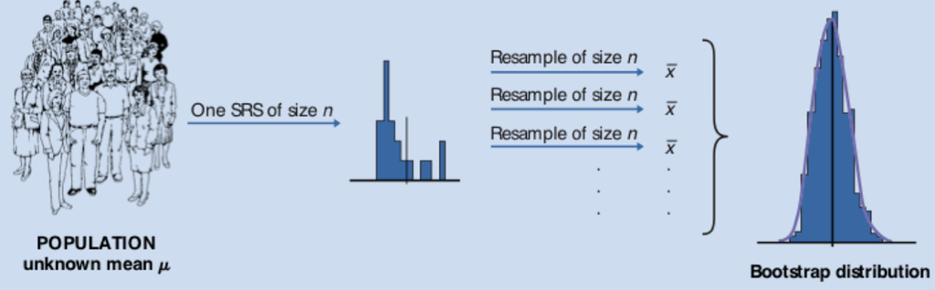

## Bootstrap distribution

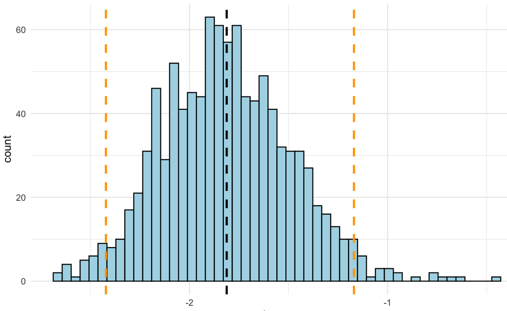

- Bootstrap distribution of 1000 regression coefficients approximates sampling distribution
- Standard deviation of the bootstrap distribution approximates the standard error
- 95% confidence interval limits: 2.5 and 97.5 percentiles

## Example with mammals sleep data

```r
subset_mammals <- mammals %>%
  select(total_sleep, brain_wt, danger) %>%
  na.omit()

summary(subset_mammals)
```

```
  total_sleep       brain_wt            danger
 Min.   : 2.60   Min.   :   0.140   Min.   :1.000
 1st Qu.: 8.05   1st Qu.:   3.925   1st Qu.:1.000
 Median :10.45   Median :  14.000   Median :2.000
 Mean   :10.53   Mean   : 281.230   Mean   :2.534
 3rd Qu.:13.20   3rd Qu.: 147.625   3rd Qu.:4.000
 Max.   :19.90   Max.   :5712.000   Max.   :5.000
```

## Exploring the data

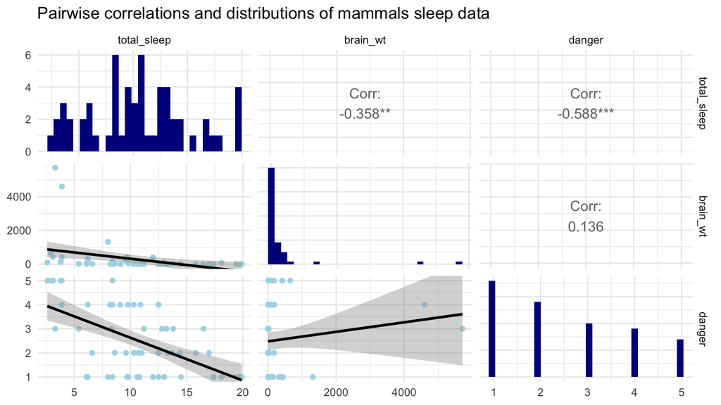

Doubts about normality: skewed distributions of `brain_wt`, variable `danger` with 5 levels.

## Linear regression

Fit a linear regression with `total_sleep` as outcome variable and `brain_wt` and `danger` as predictor variables.

```r
fit_mammals <- lm(total_sleep ~ brain_wt + danger, data = subset_mammals)
summary(fit_mammals)
```

```
Call:
lm(formula = total_sleep ~ brain_wt + danger, data = subset_mammals)

Residuals:
   Min     1Q Median     3Q    Max
-7.580 -2.602 -0.293  2.677  6.439

Coefficients:
              Estimate Std. Error t value Pr(>|t|)
(Intercept) 15.5218536  0.9774623  15.880  < 2e-16 ***
brain_wt    -0.0013603  0.0004959  -2.743   0.0082 **
danger      -1.8175407  0.3418230  -5.317 1.98e-06 ***
---
Signif. codes:  0 '***' 0.001 '**' 0.01 '*' 0.05 '.' 0.1 ' ' 1

Residual standard error: 3.559 on 55 degrees of freedom
Multiple R-squared:  0.4242,    Adjusted R-squared:  0.4033
F-statistic: 20.26 on 2 and 55 DF,  p-value: 2.553e-07
```

## 95% Confidence Interval

Obtain 95% confidence intervals (theoretical):

```r
(CI95  <- confint(fit_mammals)) %>% round(digits=4)
```

```
              2.5 %  97.5 %
(Intercept) 13.5630 17.4807
brain_wt    -0.0024 -0.0004
danger      -2.5026 -1.1325
```

## Program bootstrap function

## First draft of the function

Obtain bootstrap distribution for regression coefficient of `brain_wt`

```r
bootsample <- dplyr::slice_sample(subset_mammals, n = nrow(subset_mammals), replace = TRUE)

bootfit    <- lm(total_sleep ~ brain_wt, data = bootsample)

bootpars   <- bootfit$coef
```

## Container objects

To save statistics for multiple bootstrap samples, make a container object

- Example for 3 bootstrap samples

```r
output  <- matrix(nrow = 3, ncol = 2,
                  dimnames = list(NULL, c("(Intercept)", "brain_wt")))

output
```

```
     (Intercept) brain_wt
[1,]          NA       NA
[2,]          NA       NA
[3,]          NA       NA
```

## Looping

To save parameters of each loop, use the container object:

```r
for (i in 1:3) {

  bootsample  <- dplyr::slice_sample(subset_mammals, n = nrow(subset_mammals), replace = TRUE)

  bootfit     <- lm(total_sleep ~ brain_wt, bootsample)

  output[i, ] <- bootfit$coef

}

output
```

```
     (Intercept)     brain_wt
[1,]    11.35066 -0.001671055
[2,]    10.64652 -0.001509260
[3,]    12.20276 -0.002077569
```

## What happens at each iteration

At each iteration, a new set of coefficients (a row) is added to the container object

```r
for (i in 1:3) {

  # Bootstrap sample
  bootsample <- dplyr::slice_sample(subset_mammals, n = nrow(subset_mammals), replace = TRUE)

  # Fit model
  bootfit <- lm(total_sleep ~ brain_wt, data = bootsample)

  # Store coefficients
  output[i, ] <- bootfit$coef

  # Print current state of output
  cat("\n--- Iteration", i, "---\n")
  print(output)
}
```

```
--- Iteration 1 ---
     (Intercept)     brain_wt
[1,]    11.65839 -0.001786714
[2,]          NA           NA
[3,]          NA           NA

--- Iteration 2 ---
     (Intercept)     brain_wt
[1,]    11.65839 -0.001786714
[2,]    11.95361 -0.009137835
[3,]          NA           NA

--- Iteration 3 ---
     (Intercept)     brain_wt
[1,]    11.65839 -0.001786714
[2,]    11.95361 -0.009137835
[3,]    10.67486 -0.001607649
```

## Bootstrap function

Include argument `B` for number of bootstrap samples (with default 500)

```r
bootstrap <- function(B = 500) {

output  <- matrix(nrow = B, ncol = 2,
                  dimnames = list(NULL, c("(Intercept)", "brain_wt")))

  for (i in 1:B) {

    bootsample  <- dplyr::slice_sample(.data = data, n = nrow(data), replace = TRUE)

    bootfit     <- lm(formula = total_sleep ~ brain_wt, data = bootsample)

    output[i, ] <- bootfit$coef
  }

  return(output)
}
```

## General bootstrap function

Include the arguments `formula` and `data`

- extract the parameter names from `lm` object to use in `output`

```r
bootstrap <- function(formula, data, B = 1000) {

  pars    <- lm(formula = formula, data = data) %>% coef() %>% names()

  output  <- matrix(nrow = B, ncol = length(pars),
                    dimnames = list(NULL, pars))

  for (i in 1:B) {
    bootsample  <- dplyr::slice_sample(.data = data, n = nrow(data), replace = TRUE)
    bootfit     <- lm(formula = formula, data = bootsample)
    output[i, ] <- bootfit$coef
  }

  return(output)
}
```

## Test the bootstrap function

Bootstrapping the parameters of the linear regression model 15 times.

Set a random number seed to make the results reproducible.

```r
set.seed(848)
(boot_mammals <- bootstrap(formula = total_sleep ~ brain_wt + danger, data = subset_mammals, B = 15) %>%
    round(3))
```

```
      (Intercept) brain_wt danger
 [1,]      14.457   -0.001 -1.510
 [2,]      18.873   -0.001 -2.716
 [3,]      15.757   -0.001 -2.126
 [4,]      14.841   -0.001 -1.660
 [5,]      15.495   -0.002 -1.544
 [6,]      17.169   -0.001 -2.226
 [7,]      15.870   -0.001 -1.852
 [8,]      15.539   -0.001 -1.912
 [9,]      16.005   -0.002 -1.919
[10,]      14.889   -0.001 -1.766
[11,]      15.596   -0.001 -1.924
[12,]      16.247   -0.001 -2.107
[13,]      16.874   -0.001 -2.164
[14,]      16.598   -0.002 -2.154
[15,]      14.755   -0.001 -1.553
```

## Obtain results with bootstrap function

## Run the bootstrap function for *B* = 1000 samples

Run the bootstrap function on the mammals sleep data with outcome variable total sleep and predictors brain weight and exposure to danger. Store the results.

```r
set.seed(848)
boot_mammals <- bootstrap(formula = total_sleep ~ brain_wt + danger, data = subset_mammals)
```

## Plot bootstrap distributions

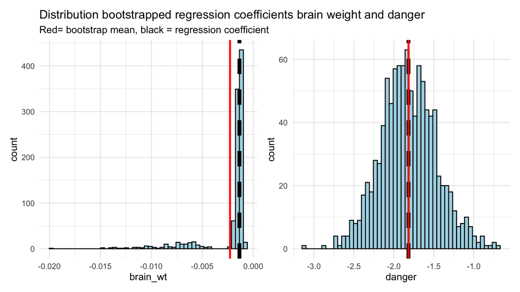

## Bootstrap and theoretical 95% CI

Obtain bootstrap 95% percentile confidence intervals (empirical):

```r
(CI95_boot <- apply(boot_mammals, 2, function(x) quantile(x, probs = c(.025, .975))) %>%
   round(4) %>%
   t())
```

```
               2.5%   97.5%
(Intercept) 13.2427 17.9019
brain_wt    -0.0104 -0.0010
danger      -2.4833 -1.0867
```

Theoretical 95% confidence intervals (based on mathematical theory, \(t\)-distribution):

```r
(CI95  <- confint(fit_mammals) %>% round(4))
```

```
              2.5 %  97.5 %
(Intercept) 13.5630 17.4807
brain_wt    -0.0024 -0.0004
danger      -2.5026 -1.1325
```

## Compare confidence intervals

Compare confidence intervals:

```r
(CI95_boot  - (CI95) %>% round(2))
```

```
               2.5%   97.5%
(Intercept) -0.3173  0.4219
brain_wt    -0.0104 -0.0010
danger       0.0167  0.0433
```

## Compare theoretical and bootstrap 95% CI

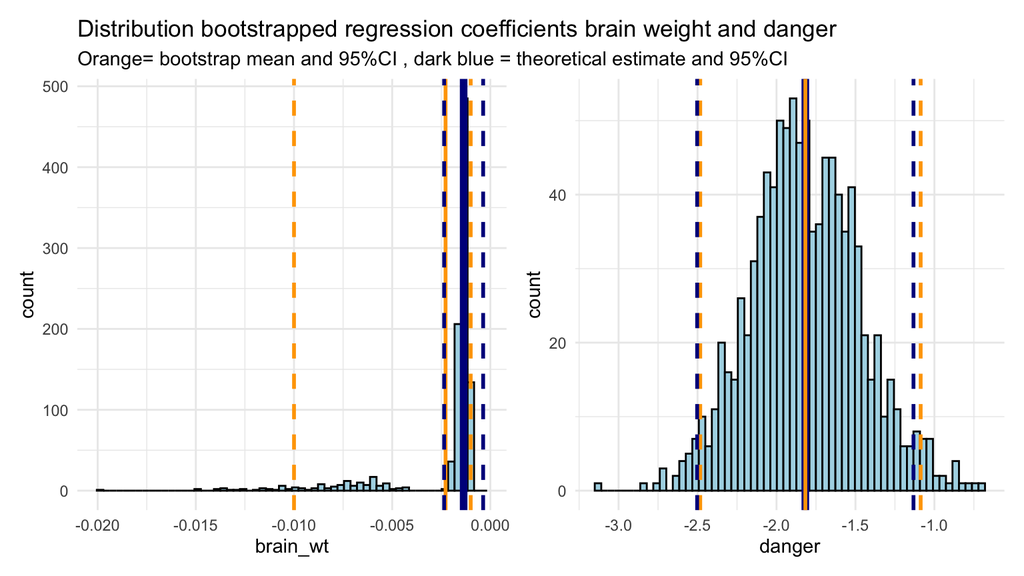

## Sourcing

## Source file

If you have written a function:

1. Save it in an R script, e.g. “my_bootstrap.R”
2. Make the function available by sourcing the script, e.g.
   - in your Rmd file, include the R chunk

```r
source("my_bootstrap.R")
```

## Bootstrap: recommendations

Use the bootstrap when you suspect that assumptions are violated, or when theoretical estimates are not possible.

The bootstrap does not solve the problem of violated assumptions: the bootstrap cannot be used to obtain better estimates.

The bootstrap confidence interval compared to theoretical interval will give insight in how violations of assumptions might influence the results.

## Lab

## Lab 4b

- Download the files of Lecture and Lab 4b
- See: Course Manual -> Thursday -> Course Materials
- Use the template file 4b to start programming the bootstrap